# tugas_akhir_kelompok

Riofebri Prasetia (221911192)

5/25/2022

```r
library('MVN')
```

```r
url <- "https://raw.githubusercontent.com/rii92/tugas-APG/main/tugas_akhir_kelompok/apgTugasAkhirKelompok4_2022/IDI_provinsi.csv"
data <- read.csv(url)[1:34,] #ambil data provinsi, bukan indonesia
head(data)
```

```
##           Provinsi X2018KS X2018HP X2018LD X2019KS X2019HP X2019LD X2020KS
## 1             ACEH   96.79   68.09   77.67   93.28   65.22   79.08   84.49
## 2   SUMATERA UTARA   76.54   62.61   51.69   72.54   61.59   71.12   77.33
## 3   SUMATERA BARAT   55.32   62.84   88.52   56.58   61.06   92.21   66.59
## 4             RIAU   86.88   62.77   89.47   85.15   61.68   84.19   86.08
## 5            JAMBI   72.88   62.76   72.92   76.67   64.63   69.21   82.71
## 6 SUMATERA SELATAN   83.13   73.12   76.01   80.54   81.95   72.23   80.32
##   X2020HP X2020LD
## 1   64.94   74.91
## 2   60.27   57.52
## 3   66.80   90.91
## 4   65.40   83.46
## 5   62.98   86.45
## 6   71.39   73.25
```

```r
#tahun 2018
data18 <- data[,1:4]
#tahun 2019
data19 <- data[,c(1,5,6,7)]
#tahun 2020
data20 <- data[,c(1,8,9,10)]
```

```r
mvn(data = data18[,2:4])$Descriptives
```

```
##          n     Mean  Std.Dev Median   Min   Max    25th    75th       Skew
## X2018KS 34 83.39147 9.195589 82.620 55.32 97.36 77.5375 90.8925 -0.6289414
## X2018HP 34 65.02412 8.788896 64.415 40.11 83.03 62.1050 71.2700 -0.5507803
## X2018LD 34 75.54118 9.938994 76.560 51.69 89.55 72.3275 80.4250 -0.6735013
##           Kurtosis
## X2018KS  0.4994926
## X2018HP  0.5478098
## X2018LD -0.1203924
```

```r
mvn(data = data19[,2:4])$Descriptives
```

```
##          n     Mean   Std.Dev Median   Min   Max    25th    75th        Skew
## X2019KS 34 83.09559 10.232532 84.635 56.58 96.60 77.0925 92.6425 -0.59761669
## X2019HP 34 68.03294  9.477796 67.090 50.31 86.52 62.1450 74.4825 -0.05650974
## X2019LD 34 76.54471 10.440947 78.130 52.61 92.21 69.5950 82.5450 -0.43080382
##           Kurtosis
## X2019KS -0.5196854
## X2019HP -0.7800315
## X2019LD -0.3179011
```

```r
mvn(data = data20[,2:4])$Descriptives
```

```
##          n     Mean   Std.Dev Median   Min   Max    25th    75th        Skew
## X2020KS 34 84.74882  9.122999 86.205 66.59 97.93 79.4200 92.4700 -0.46880654
## X2020HP 34 66.67088  8.290763 66.190 47.78 84.95 62.9050 71.5775 -0.07403505
## X2020LD 34 74.78735 10.270507 75.180 53.09 92.97 68.3275 80.9250 -0.16618099
##            Kurtosis
## X2020KS -0.84450584
## X2020HP -0.09725756
## X2020LD -0.55724176
```

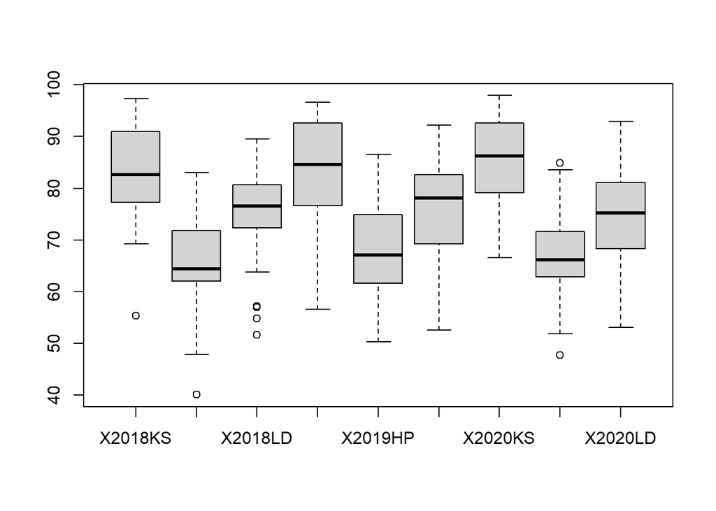

```r
boxplot(c(data18[,2:4], data19[,2:4], data20[,2:4]))
```

Perlu dilakukan standarisasi agar memiliki skala nilai yang sama antar kolom

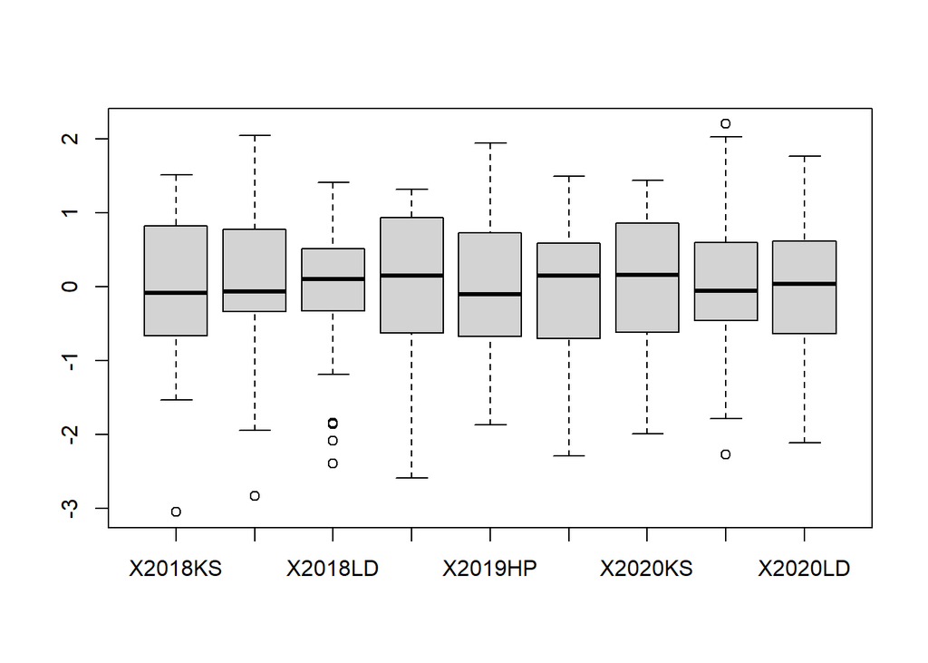

```r
data18_std <- data18
data19_std <- data19
data20_std <- data20

## Lakukan standarisasi
data18_std[,2:4] <- scale(data18[,2:4])
data19_std[,2:4] <- scale(data19[,2:4])
data20_std[,2:4] <- scale(data20[,2:4])

# Boxplot setelah standarisasi
boxplot(c(data18_std[,2:4], data19_std[,2:4], data20_std[,2:4]))
```

## Untuk tahun 2018

boxplot setelah standarisasi

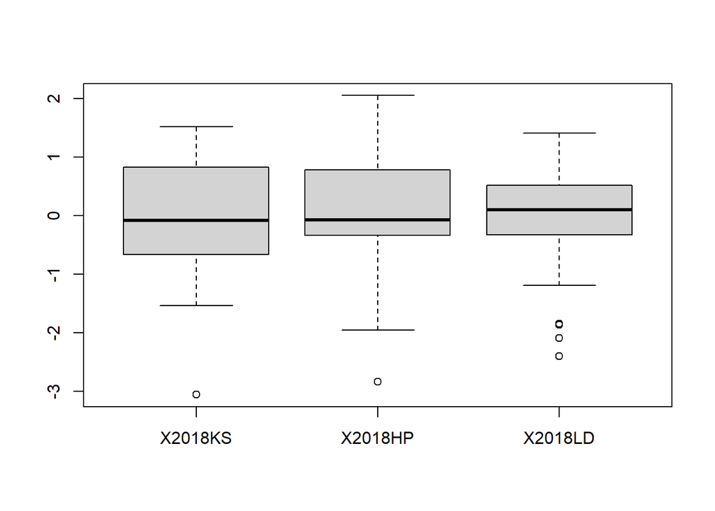

```r
boxplot(c(data18_std[,2:4]))
```

akan di lakukan pengelompokkan data pada setiap tahun

```r
## melakukan penghapusan outlier
data18_std <- na.omit(data18_std)
head(data18_std)
```

```
##           Provinsi     X2018KS    X2018HP     X2018LD
## 1             ACEH  1.45706056  0.3488359  0.21418904
## 2   SUMATERA UTARA -0.74508233 -0.2746781 -2.39975765
## 3   SUMATERA BARAT -3.05271059 -0.2485088  1.30584884
## 4             RIAU  0.37936989 -0.2564734  1.40143195
## 5            JAMBI -1.14309927 -0.2576112 -0.26372654
## 6 SUMATERA SELATAN -0.02843435  0.9211490  0.04717012
```

```r
mvn(data18_std[,2:4], showOutliers = TRUE)$multivariateOutliers
```

Secara multivariate tidak ada outlier sehingga proses tetap dilanjutkan

```r
library(factoextra)
euclidean1 <- get_dist(data18_std)
```

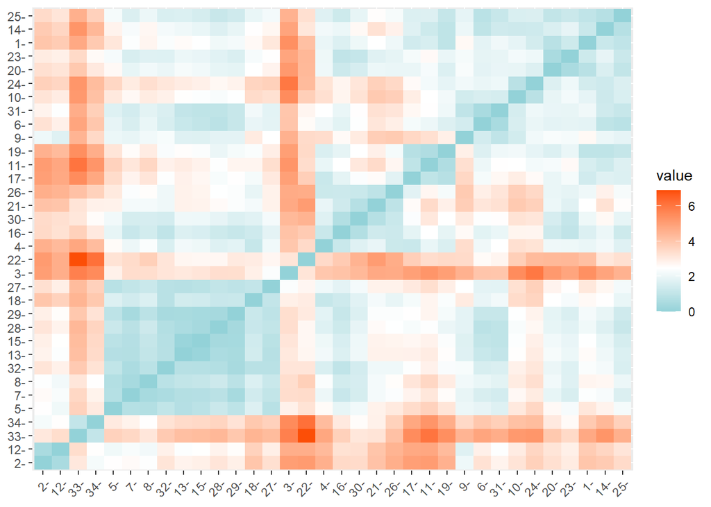

```r
fviz_dist(euclidean1, gradient = list(low = "#00AFBB", mid = "white", high =
"#FC4E07"))
```

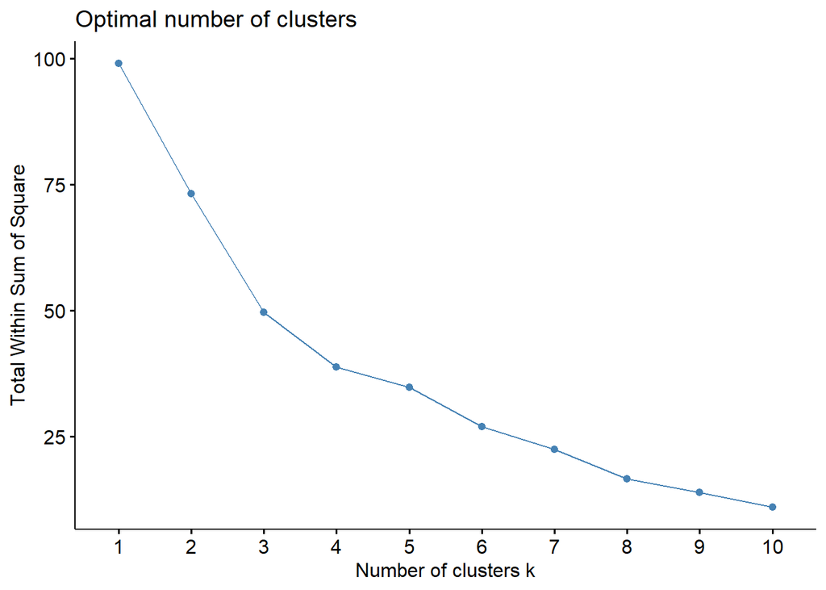

```r
library(factoextra)
set.seed(123)
fviz_nbclust(data18_std[,2:4], kmeans, method = "wss")
```

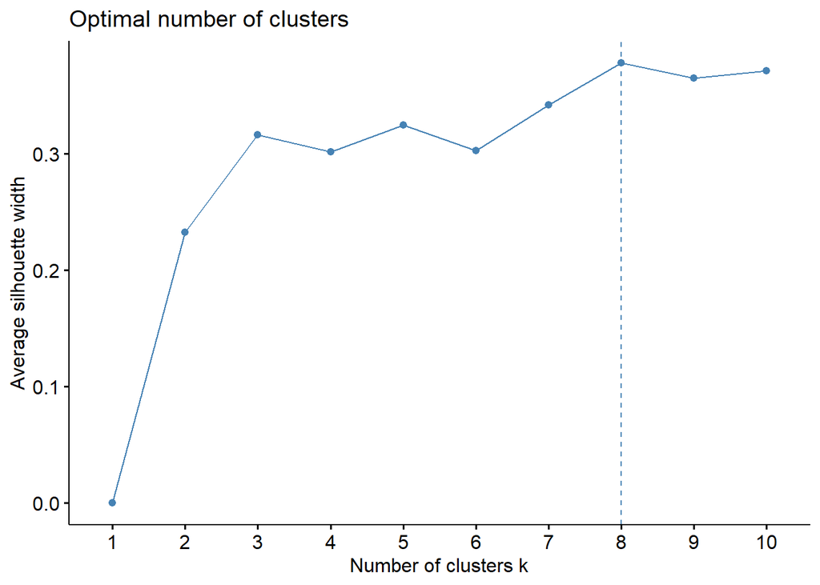

```r
set.seed(123)
fviz_nbclust(data18_std[,2:4], kmeans, method = "silhouette")
```

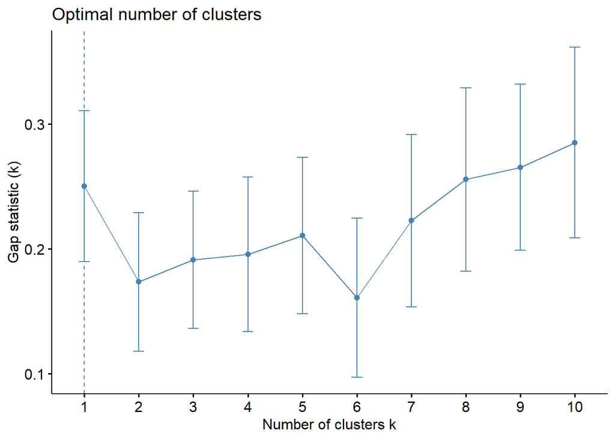

```r
library(cluster)
set.seed(123)
gap_stat1 <- clusGap(data18_std[,2:4], FUN = kmeans, K.max = 10, B = 50)
fviz_gap_stat(gap_stat1)
```

2. Berdasarkan pencarian k optimal di Silhouette maka titik yang mengalami penurunan terbesar kemudian menjadi landai setelah melalui titik tersebut ialah k = 8
3. Berdasarkan pencarian k optimal di Gap Statistic maka titik yang mengalami penurunan terbesar kemudian menjadi landai setelah melalui titik tersebut ialah k = 1

dengan menggunakan k = 4, akan ada kemungkinan terjadinya overlap. Jadinya dari kami akan mencoba untuk menurunkan jumlah cluster menjadi 3 cluster. k = 3

```r
library(stats)
set.seed(123)
endkmeans18 <- kmeans(data18_std[,2:4], 3, nstart = 25)
print(endkmeans18)
```

```
## K-means clustering with 3 clusters of sizes 15, 15, 4
##
## Cluster means:
##      X2018KS    X2018HP    X2018LD
## 1  0.9088992  0.1118702  0.3726893
## 2 -0.7953963  0.2271672  0.1734069
## 3 -0.4256357 -1.2713904 -2.0478609
##
## Clustering vector:
##  1  2  3  4  5  6  7  8  9 10 11 12 13 14 15 16 17 18 19 20 21 22 23 24 25 26
##  1  3  2  1  2  2  2  2  2  1  1  3  2  1  2  1  1  2  1  1  1  2  1  1  1  1
## 27 28 29 30 31 32 33 34
##  2  2  2  1  2  2  3  3
##
## Within cluster sum of squares by cluster:
## [1] 22.432512 20.866608  6.357945
##  (between_SS / total_SS =  49.8 %)
##
## Available components:
##
## [1] "cluster"      "centers"      "totss"        "withinss"     "tot.withinss"
## [6] "betweenss"    "size"         "iter"         "ifault"
```

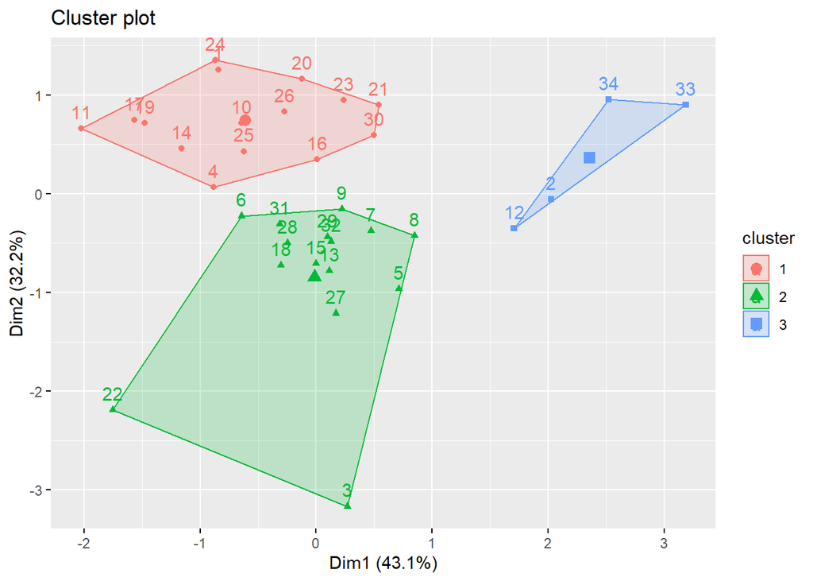

```r
fviz_cluster(endkmeans18, data = data18_std[,2:4])
```

Dalam hal ini, bisa kita lihat bahwa kemungkinan untuk overlap tidak ada

```r
#cek cluster
data18_afterCluster <- data.frame(data18, endkmeans18$cluster)
data18_afterCluster[,c(1,5)]
```

```
##                Provinsi endkmeans18.cluster
## 1                  ACEH                   1
## 2        SUMATERA UTARA                   3
## 3        SUMATERA BARAT                   2
## 4                  RIAU                   1
## 5                 JAMBI                   2
## 6      SUMATERA SELATAN                   2
## 7              BENGKULU                   2
## 8               LAMPUNG                   2
## 9  KEP. BANGKA BELITUNG                   2
## 10            KEP. RIAU                   1
## 11          DKI JAKARTA                   1
## 12           JAWA BARAT                   3
## 13          JAWA TENGAH                   2
## 14        DI YOGYAKARTA                   1
```

[output cut: 20 more lines]

Terdapat 3 cluster yang dibentuk berdasarkan aspek kebebasan sipil, aspek hak-hak politik, aspek lembaga demokrasi

## Untuk data tahun 2019

Boxplot setelah standarisasi

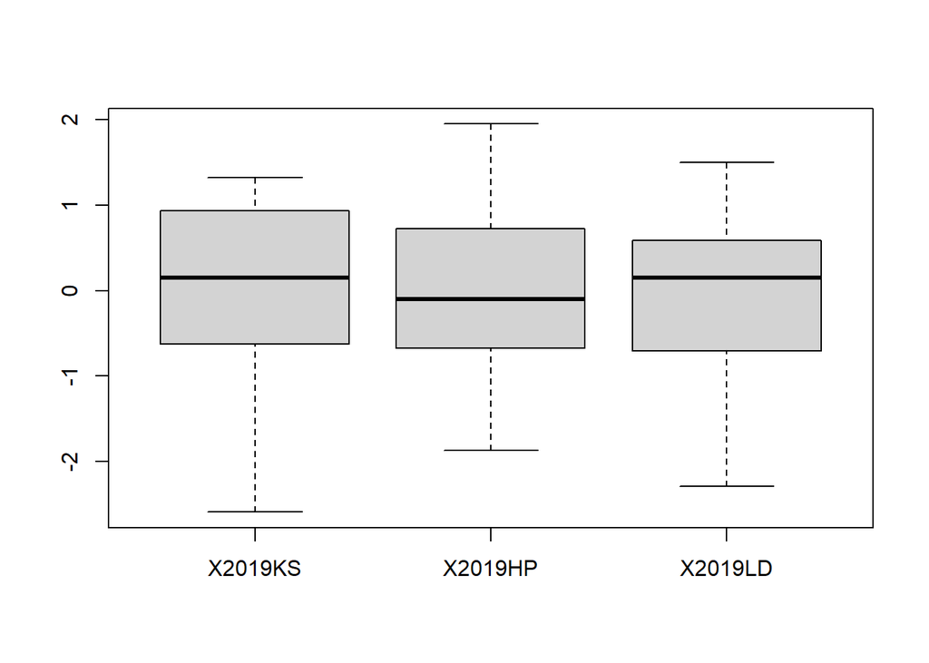

```r
boxplot(c(data19_std[,2:4]))
```

akan di lakukan pengelompokkan data pada setiap tahun

```r
## 2019 Mencoba membuang outlier
data19_std <- na.omit(data19_std)
head(data19_std)
```

```
##           Provinsi    X2019KS    X2019HP    X2019LD
## 1             ACEH  0.9952974 -0.2967928  0.2428222
## 2   SUMATERA UTARA -1.0315715 -0.6797932 -0.5195607
## 3   SUMATERA BARAT -2.5913028 -0.7357134  1.5003710
## 4             RIAU  0.2007726 -0.6702973  0.7322415
## 5            JAMBI -0.6279568 -0.3590435 -0.7024943
## 6 SUMATERA SELATAN -0.2497513  1.4683856 -0.4132485
```

```r
mvn(data19_std[,2:4], showOutliers = TRUE)$outliers
```

Secara multivariate tidak ada outlier sehingga proses tetap dilanjutkan

```r
library(factoextra)
euclidean2 <- get_dist(data19_std)
```

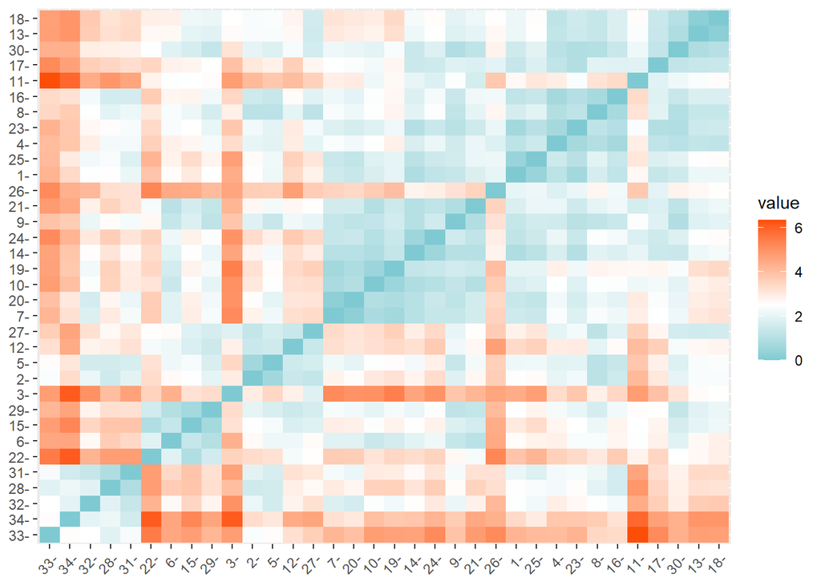

```r
fviz_dist(euclidean2, gradient = list(low = "#00AFBB", mid = "white", high =
"#FC4E07"))
```

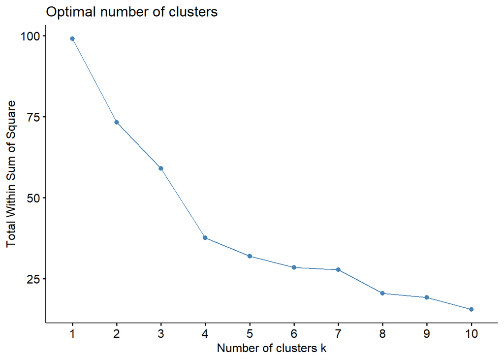

```r
library(factoextra)
set.seed(123)
fviz_nbclust(data19_std[,2:4], kmeans, method = "wss")
```

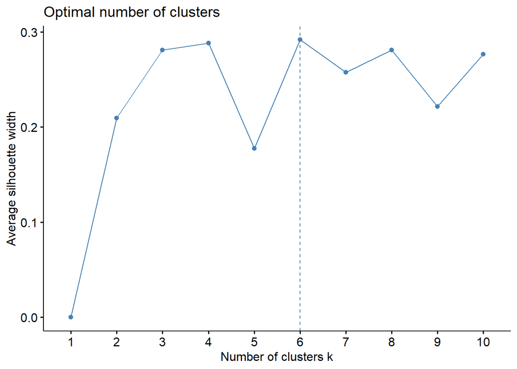

```r
set.seed(123)
fviz_nbclust(data19_std[,2:4], kmeans, method = "silhouette")
```

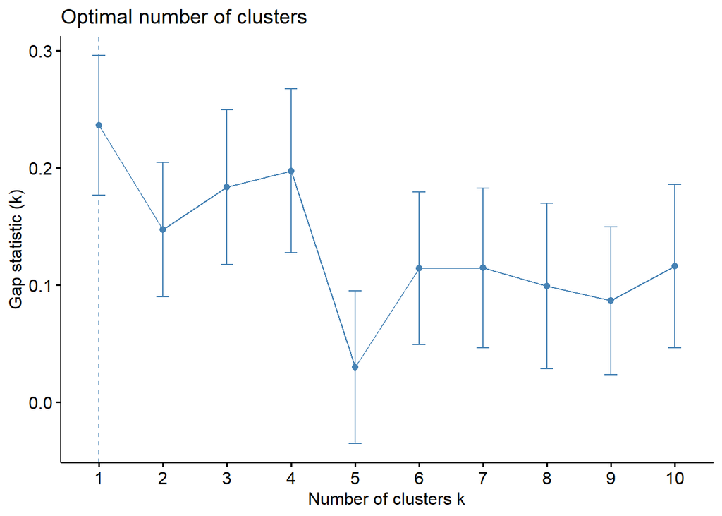

```r
library(cluster)
set.seed(123)
gap_stat2 <- clusGap(data19_std[,2:4], FUN = kmeans, K.max = 10, B = 50)
fviz_gap_stat(gap_stat2)
```

2. Berdasarkan pencarian k optimal di Silhouette maka titik yang mengalami penurunan terbesar kemudian menjadi landai setelah melalui titik tersebut ialah k = 6
3. Berdasarkan pencarian k optimal di Gap Statistic maka titik yang mengalami penurunan terbesar kemudian menjadi landai setelah melalui titik tersebut ialah k = 1

Dari kami tetap memilih 3 cluster sehingga hasil cluster tetap seperti sebagai berikut

```r
library(stats)
set.seed(123)
endkmeans19 <- kmeans(data19_std[,2:4], 3, nstart = 25)
print(endkmeans19)
```

```
## K-means clustering with 3 clusters of sizes 5, 13, 16
##
## Cluster means:
##       X2019KS    X2019HP    X2019LD
## 1  0.01821756 -1.3934612 -1.6727128
## 2 -0.96436505  0.2697135  0.3402198
## 3  0.77785362  0.2163144  0.2462941
##
## Clustering vector:
##  1  2  3  4  5  6  7  8  9 10 11 12 13 14 15 16 17 18 19 20 21 22 23 24 25 26
##  3  2  2  3  2  2  3  2  3  3  3  2  2  3  2  3  3  2  3  3  3  2  3  3  3  3
## 27 28 29 30 31 32 33 34
##  2  1  2  2  1  1  1  1
##
## Within cluster sum of squares by cluster:
## [1]  5.910945 21.997452 21.450855
##  (between_SS / total_SS =  50.1 %)
##
## Available components:
##
## [1] "cluster"      "centers"      "totss"        "withinss"     "tot.withinss"
## [6] "betweenss"    "size"         "iter"         "ifault"
```

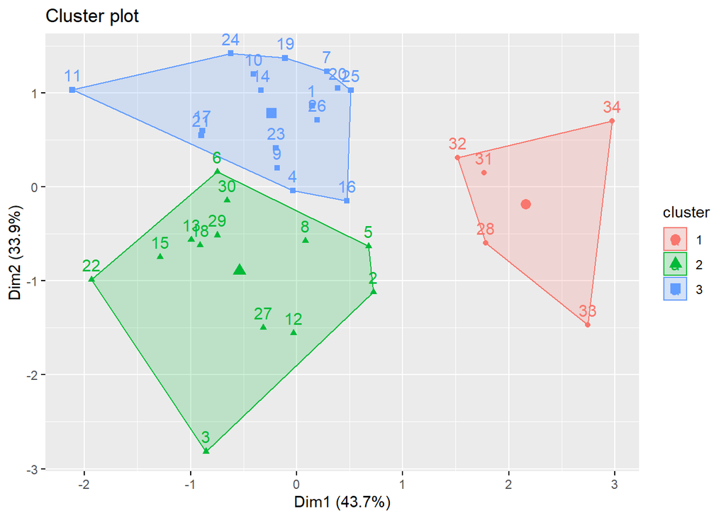

```r
fviz_cluster(endkmeans19, data = data19_std[,2:4])
```

```r
#cek cluster
data19_afterCluster <- data.frame(data19, endkmeans19$cluster)
data19_afterCluster[,c(1,5)]
```

```
##                Provinsi endkmeans19.cluster
## 1                  ACEH                   3
## 2        SUMATERA UTARA                   2
## 3        SUMATERA BARAT                   2
## 4                  RIAU                   3
## 5                 JAMBI                   2
## 6      SUMATERA SELATAN                   2
## 7              BENGKULU                   3
## 8               LAMPUNG                   2
## 9  KEP. BANGKA BELITUNG                   3
## 10            KEP. RIAU                   3
## 11          DKI JAKARTA                   3
## 12           JAWA BARAT                   2
## 13          JAWA TENGAH                   2
## 14        DI YOGYAKARTA                   3
```

[output cut: 20 more lines]

## Untuk data tahun 2020

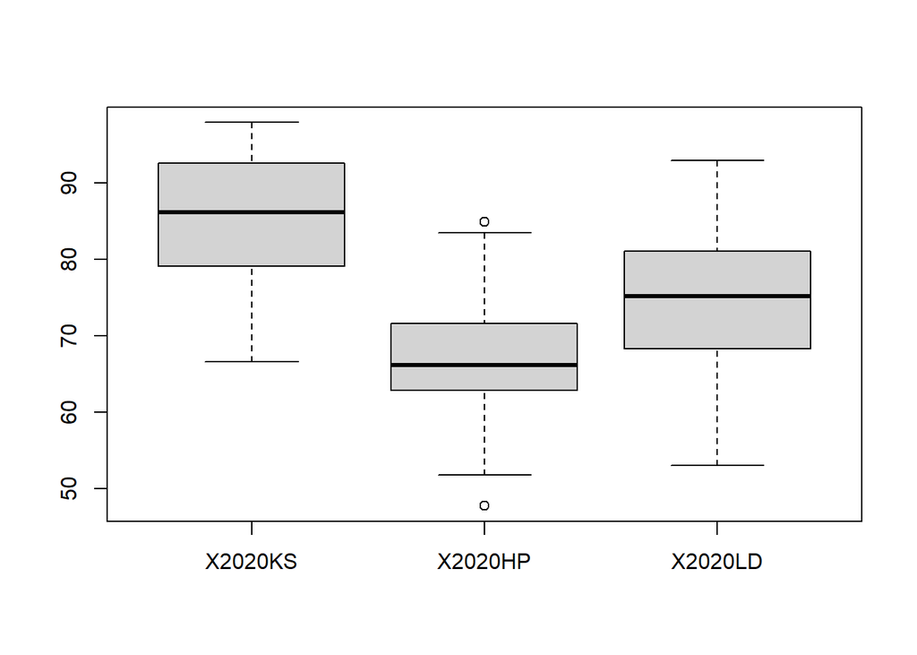

```r
boxplot(c(data20[,2:4]))
```

```r
## 2020
data20_std <- na.omit(data20_std)
head(data20_std)
```

```
##           Provinsi     X2020KS     X2020HP     X2020LD
## 1             ACEH -0.02837044 -0.20877239  0.01194168
## 2   SUMATERA UTARA -0.81320004 -0.77204987 -1.68125611
## 3   SUMATERA BARAT -1.99044443  0.01557368  1.56980048
## 4             RIAU  0.14591434 -0.15328895  0.84442247
## 5            JAMBI -0.22348171 -0.44518007  1.13554734
## 6 SUMATERA SELATAN -0.48545695  0.56920187 -0.14968618
```

```r
mvn(data20_std[,2:4], showOutliers = TRUE)$outliers
```

Secara multivariate tidak ada outlier sehingga proses tetap dilanjutkan

```r
library(factoextra)
euclidean3 <- get_dist(data20_std)
```

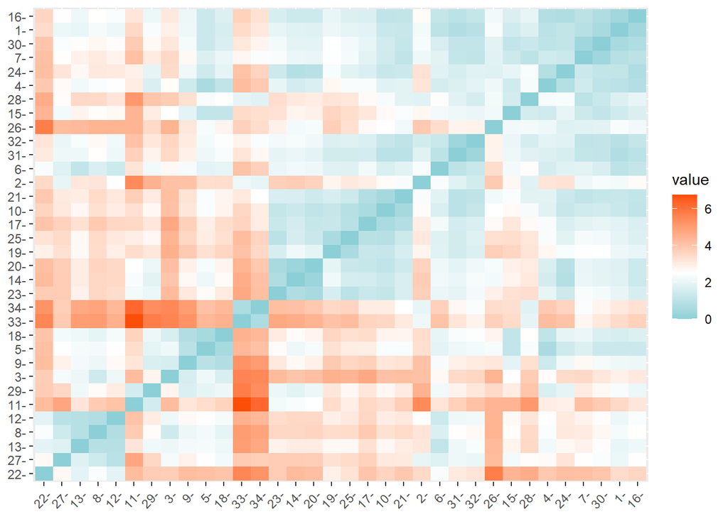

```r
fviz_dist(euclidean3, gradient = list(low = "#00AFBB", mid = "white", high =
"#FC4E07"))
```

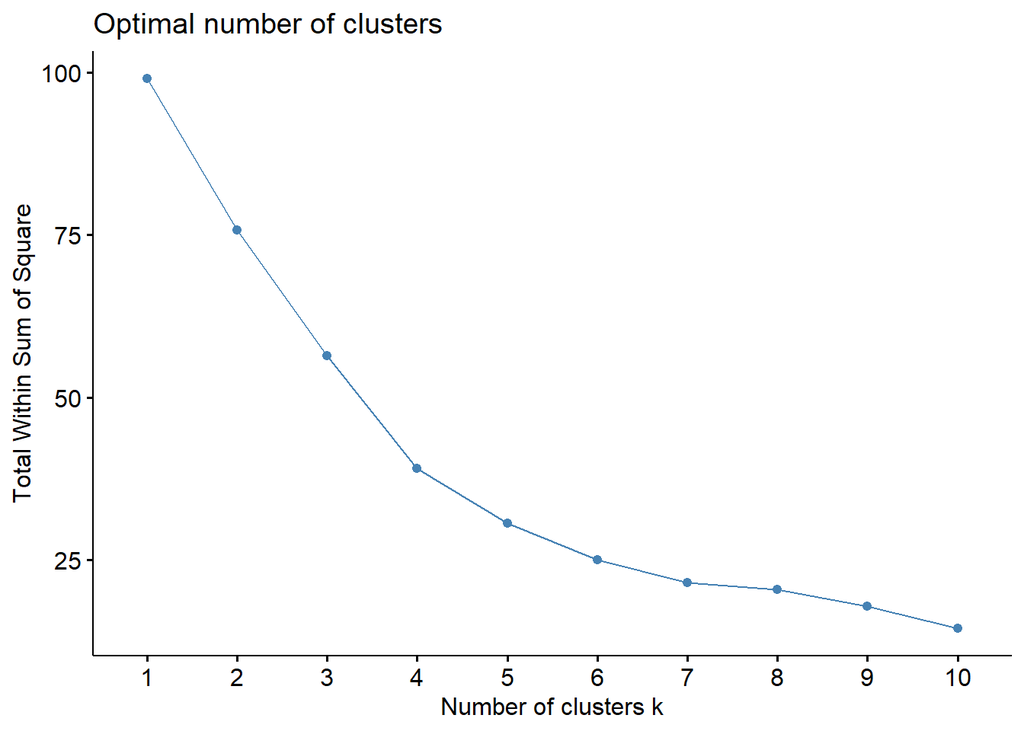

```r
library(factoextra)
set.seed(123)
fviz_nbclust(data20_std[,2:4], kmeans, method = "wss")
```

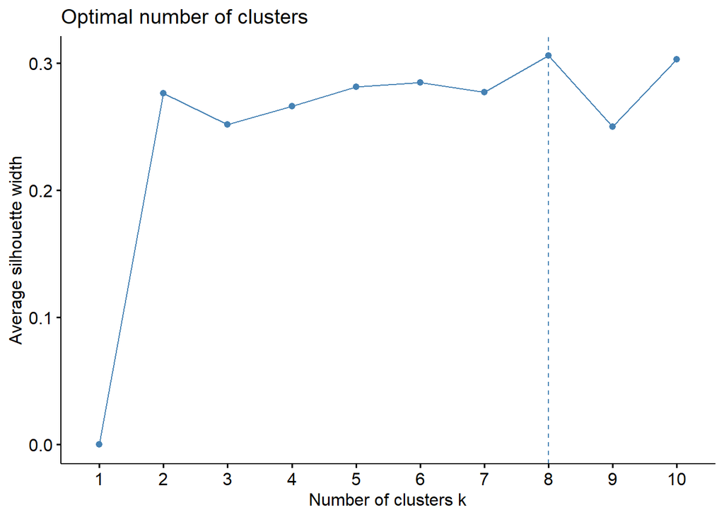

```r
set.seed(123)
fviz_nbclust(data20_std[,2:4], kmeans, method = "silhouette")
```

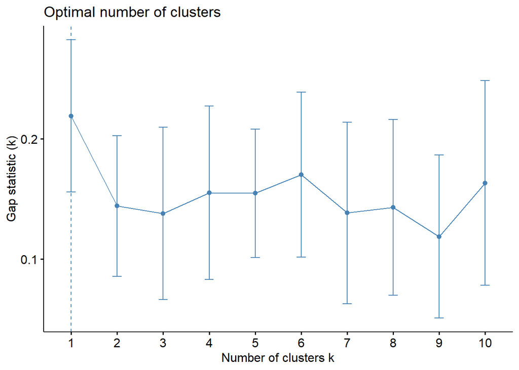

```r
library(cluster)
set.seed(123)
gap_stat3 <- clusGap(data20_std[,2:4], FUN = kmeans, K.max = 10, B = 10)
fviz_gap_stat(gap_stat3)
```

2. Berdasarkan pencarian k optimal di Silhouette maka titik yang mengalami penurunan terbesar kemudian menjadi landai setelah melalui titik tersebut ialah k = 8
3. Berdasarkan pencarian k optimal di Gap Statistic maka titik yang mengalami penurunan terbesar kemudian menjadi landai setelah melalui titik tersebut ialah k = 1

Dari kami tetap memilih 3 cluster, hasilnya sebagai berikut:

```r
library(stats)
set.seed(123)
endkmeans20 <- kmeans(data20_std[,2:4], 3, nstart = 25)
print(endkmeans20)
```

```
## K-means clustering with 3 clusters of sizes 18, 12, 4
##
## Cluster means:
##       X2020KS    X2020HP     X2020LD
## 1  0.69757257  0.1568956 -0.02749163
## 2 -1.03352231  0.2993232  0.57739574
## 3 -0.03850965 -1.6039999 -1.60847490
##
## Clustering vector:
##  1  2  3  4  5  6  7  8  9 10 11 12 13 14 15 16 17 18 19 20 21 22 23 24 25 26
##  1  3  2  1  2  2  1  2  2  1  1  2  2  1  2  1  1  2  1  1  1  2  1  1  1  1
## 27 28 29 30 31 32 33 34
##  2  3  2  1  1  1  3  3
##
## Within cluster sum of squares by cluster:
## [1] 24.546105 23.032165  3.666355
##  (between_SS / total_SS =  48.2 %)
##
## Available components:
##
## [1] "cluster"      "centers"      "totss"        "withinss"     "tot.withinss"
## [6] "betweenss"    "size"         "iter"         "ifault"
```

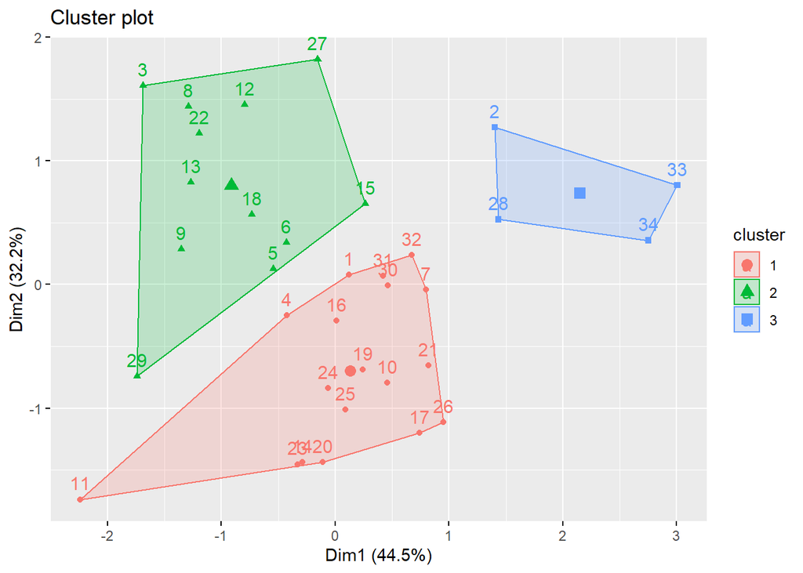

```r
fviz_cluster(endkmeans20, data = data20_std[,2:4])
```

```r
#cek cluster
data20_afterCluster <- data.frame(data20, endkmeans20$cluster)
data20_afterCluster[,c(1,5)]
```

```
##                Provinsi endkmeans20.cluster
## 1                  ACEH                   1
## 2        SUMATERA UTARA                   3
## 3        SUMATERA BARAT                   2
## 4                  RIAU                   1
## 5                 JAMBI                   2
## 6      SUMATERA SELATAN                   2
## 7              BENGKULU                   1
## 8               LAMPUNG                   2
## 9  KEP. BANGKA BELITUNG                   2
## 10            KEP. RIAU                   1
## 11          DKI JAKARTA                   1
## 12           JAWA BARAT                   2
## 13          JAWA TENGAH                   2
## 14        DI YOGYAKARTA                   1
```

[output cut: 20 more lines]